# Tutorial - Gráfico de Radar

Juliana Degani 180034154

29/10/2019

## O que é um gráfico de Radar?

O gráfico de radar também é conhecido como gráfico de teia ou gráfico polar. É equivalente a um gráfico de coordenadas paralelas, com os eixos dispostos radialmente, onde cada raio representando uma das variáveis e cada estrela representa uma única observação. É um pouco mais fácil de ver padrões em dados se as observações forem organizadas em alguma ordem não-arbitrária (se as variáveis forem atribuídas aos raios da estrela em uma ordem significativa).

Um exemplo bem simples desse gráfico:

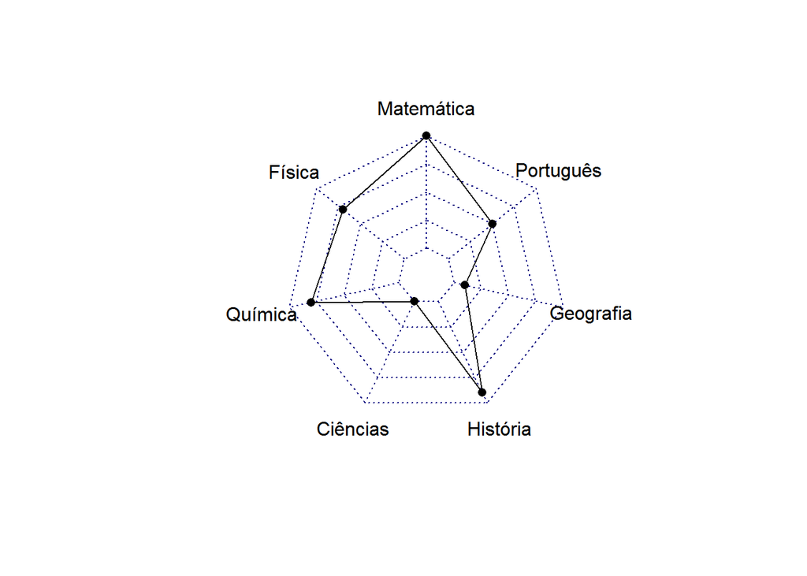

## Quando usar o gráfico de Radar?

Esse gráfico pode ser usado para responder às seguintes perguntas:

- Quais observações são mais semelhantes, ou seja, existem grupos de observações?
- Existem discrepâncias?

Como por exemplo: - Avaliar o desempenho dos alunos - Identificar quais as áreas do conhecimento cada aluno se destaca acadêmicamente - Identificar pontos fortes e fracos de atletas - Ferramenta muito utilizada em análises de perfil comportamental

## Como devem ser os dados para se criar esse tipo de gráfico?

Gráficos de radar são úteis para conjuntos de dados multivariáveis de tamanho pequeno a moderado.

## Como customizar esse gráfico no RStudio para que fique mais apresentável?

É possível fazer várias alterações para que o gráfico fique como o desejado, dentre elas, as mais utilizadas, são:

- Aterações no polígono formado:
  - A cor da linha: pcol
  - A cor de preenchimento: pfcol
  - A largura da linha: plwd
- Alterações na grade que aparece no fundo do gráfico:
  - Cor da rede: cgcol
  - Tipo de linha: cglty
  - Cor dos rótulos dos eixos; axisbcol
  - largura da rede: cglwd
- Alterar os rótulos das variáveis:
  - Tamanho dos rótulos dos grupos: vlcex

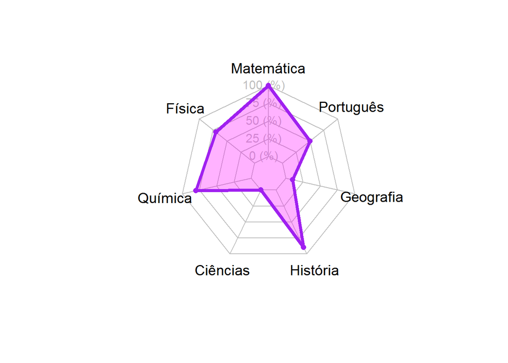

```r
radarchart( notas , axistype=1 ,

  # polígono:
  pcol="purple" ,          # altera a cor da linha
  pfcol= rgb(1,0,1, 0.3) , # altera a cor do preenchimento
                           # rgb: vermelho, verde e azul
  plwd=4 ,                 # altera a largura da linha

  # grade
  cglcol="grey",               # 3 cor da rede
  cglty=1,                     # tipo de linha
  axislabcol="grey",           # cor dos rótulos dos eixos
  cglwd=1,                     # largura da rede

  # rótulos
  vlcex=1.2 # tamanho dos rótulos
)
```

Importante ressaltar que utilizamos o comando “rgb” para escolher a cor de preenchimento do polígono, isso se deve ao fato de que desejamos uma certa transparência, para que seja possível observar as linhas de grade através do polígono.

O comando “rgb” significa “Red, Green, Blue”, que em inglês significa, Vermelho, Verde, Azul. E essa é a estrutura utilizada, onde os argumentos variam de 0 a 1 dependendo da quantidade desejada de cada uma dessas três cores e o último argumento corresponde à transparência a ser obtida com aquela cor.

## Como comparar mais de uma observação?

Como cada observação do banco de dados é representada por um polígono no gráfico de radar, para realizar comparações, basta plotar mais de uma observação para o mesmo gráfico, como por exemplo:

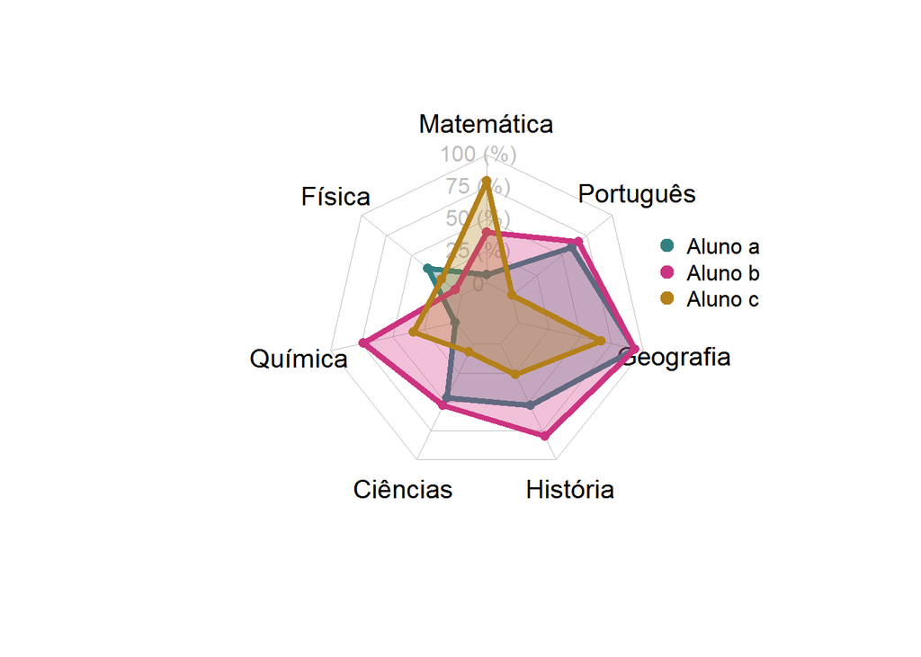

```r
# Criar os dados das notas de 3 alunos:
turma <- as.data.frame(matrix( sample( 0:15, 21 , replace=T) , ncol=7))

colnames(turma) <- c("Matemática", "Física", "Química" , "Ciências",
                     "História", "Geografia", "Português")
rownames(turma) <- paste("Aluno" , letters[1:3] , sep=" ")

# Criar os máximos e mínimos de cada nota:

turma <- rbind(rep(15,7) , rep(0,7) , turma)

# Criar as 3 cores que queremos usar com o comando rgb

cor_linha=c( rgb(0.2,0.5,0.5,1), rgb(0.8,0.2,0.5,1) , rgb(0.7,0.5,0.1,1) )
cor_preenchimento=c(rgb(0.2,0.5,0.5,0.3), rgb(0.8,0.2,0.5,0.3) , rgb(0.7,0.5,0.1,0.3) )

# Customiazações finais:

radarchart( turma  , axistype=1 ,
            # polígono
            pcol=cor_linha , pfcol=cor_preenchimento , plwd=4 , plty=1,
            # grade:
            cglcol="grey", cglty=1, axislabcol="grey", caxislabels=seq(0,15,25), cglwd=0.8,
            # rótulos
            vlcex=1.2

)
# Legenda

legend(x=1, y=0.6, # posição
       legend = rownames(turma[-c(1,2),]),
       bty = "n", pch=20 # formato
       , col=cor_linha , text.col = "black", cex=1, # distrância entre as legendas
       pt.cex=2) # tamanho
```

## Como fazer as comparações em gráficos separados?

No caso em que existem muitas comparações a serem feitas, o gráfico anterior talvez não seja a melhor opção para a vizualização dos dados, seria melhor colocá-los lado a lado da seguinte forma:

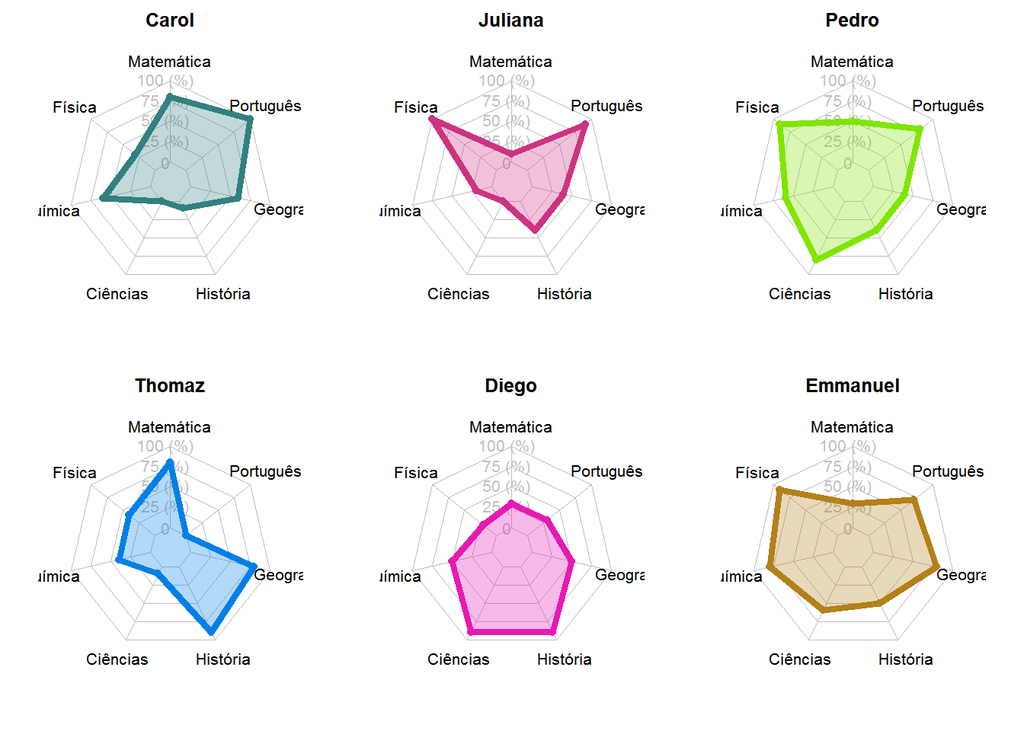

```r
set.seed(1)
# gerar as notas dos 6 alunos de forma aleatória
alunos1 <-as.data.frame(matrix( sample( 0:10 , 70 , replace=T) , ncol=7, byrow=TRUE))

# quais são as matérias:
colnames(alunos1) <- c("Matemática", "Física", "Química" , "Ciências","História",
                       "Geografia", "Português")

# para usar o pacote "fmsb", vamos adicionar as linhas de máximo e mínino ao data frame
alunos1 <-rbind(rep(10,7) , rep(0,10) , alunos1)

# Escolher as cores
cor_linha=c( rgb(0.2,0.5,0.5,1), rgb(0.8,0.2,0.5,1) ,
             rgb(0.5,0.9,0,1),   rgb(0,0.5,0.9,1),
            rgb(0.9,0.1,0.7,1) , rgb(0.7,0.5,0.1,1) )

cor_preenchimento=c(rgb(0.2,0.5,0.5,0.3), rgb(0.8,0.2,0.5,0.3) ,
                    rgb(0.5,0.9,0,0.3),rgb(0,0.5,0.9,0.3),
                    rgb(0.9,0.1,0.7,0.3),rgb(0.7,0.5,0.1,0.3))


# Nomes dos alunos
nomes <- c("Carol", "Juliana", "Pedro", "Thomaz", "Diego", "Emmanuel")

# Separar o espaço para aparecer os 6 gráficos:
par(mar=rep(2,4))
par(mfrow=c(2,3))

# Fazer o seguinte loop para que todos os gráficos fiquem padronizados
for(i in 1:6){

  # fazer para cada aluno:
  radarchart( alunos1[c(1,2,i+2),],
              axistype=1, # tipo do título

    # escolher as cores:
    pcol=cor_linha[i] , pfcol=cor_preenchimento[i] ,
    plwd=4, # largura da linha

    # grade do fundo
    cglcol="grey", cglty=1, axislabcol="grey", caxislabels=seq(0,10,20), cglwd=0.8,

    # tamanho da legenda
    vlcex=1,

    # colocar os nomes dos alunos
    title=nomes[i]
    )
}
```